# Lab5

Heather Childers

2023-02-07

This week’s lab is a musical lab. You’ll be requesting data from the Spotify API and using it to build k-nearest neighbor and decision tree models.

In order to use the Spotify API you must have a Spotify account. If you don’t have one, sign up for a free one here: https://www.spotify.com/us/signup

Once you have an account, go to Spotify for developers (https://developer.spotify.com/) and log in. Click the green “Create a Client ID” button to fill out the form to create an app create an app so you can access the API.

On your developer dashboard page, click on the new app you just created. Go to Settings -> Basic Information and you will find your Client ID . Click “View client secret” to access your secondary Client ID. Scroll down to Redirect URIs and enter: http://localhost:1410/

You have two options for completing this lab.

**Option 2: Classify by genres.** Build models that predict which genre a song belongs to. This will use a pre-existing Spotify dataset available from Kaggle.com (https://www.kaggle.com/datasets/mrmorj/dataset-of-songs-in-spotify)

```r
library(spotifyr)
library(tidyverse)
library(tidymodels)
library(rsample)
library(recipes)
library(caret)
library(vip)
library(rpart)
library(ipred)
library(doParallel)
```

```r
library(foreach)
library(ranger)
library(rpart.plot)
library(kableExtra)
```

Client ID and Client Secret are required to create and access token that is required to interact with the API. You can set them as system values so we don’t have to do provide them each time.

**Option 2: Data preparation**

Download the Spotify dataset from https://www.kaggle.com/datasets/mrmorj/dataset-of-songs-in-spotify

Inspect the data. Choose two genres you’d like to use for the classification task. Filter down the data to include only the tracks of that genre.

```r
#Grab the .csv from here:
#https://www.kaggle.com/datasets/mrmorj/dataset-of-songs-in-spotify
kaggle_dat <- read_csv("genres_v2.csv")
unique(kaggle_dat$genre)
```

```
##  [1] "Dark Trap"       "Underground Rap" "Trap Metal"      "Emo"
##  [5] "Rap"             "RnB"             "Pop"             "Hiphop"
##  [9] "techhouse"       "techno"          "trance"          "psytrance"
## [13] "trap"            "dnb"             "hardstyle"
```

```r
table(kaggle_dat$genre)
```

```
##
##       Dark Trap             dnb             Emo       hardstyle          Hiphop
##            4578            2966            1680            2936            3028
##             Pop       psytrance             Rap             RnB       techhouse
##             461            2961            1848            2099            2975
##          techno          trance            trap      Trap Metal Underground Rap
##            2956            2999            2987            1956            5875
```

```r
#Removing inappropriate columns and selecting trap and pop as the two genres here and making case consistent
genre_dat <- kaggle_dat %>%
  select(-c(type, uri, track_href, analysis_url, `Unnamed: 0`, title, tempo, id, song_name)) %>%
  filter(genre == "Pop"|genre == "trap") %>%
  mutate(genre = str_replace(genre, "Pop", "pop")) %>%
  mutate(genre = as.factor(genre))
```

**Option 2: Data preparation**

Download the Spotify dataset from https://www.kaggle.com/datasets/mrmorj/dataset-of-songs-in-spotify

Inspect the data. Choose two genres you’d like to use for the classification task. Filter down the data to include only the tracks of that genre.

**Data Exploration (both options)**

Let’s take a look at your data. Do some exploratory summary stats and visualization.

For example: What are the most danceable tracks in your dataset? What are some differences in the data between users (Option 1) or genres (Option 2)?

Pop tracks are generally more danceable than trap music, and pop tracks are generally in a higher key which makes sense because the pop genre probably has more female artists.

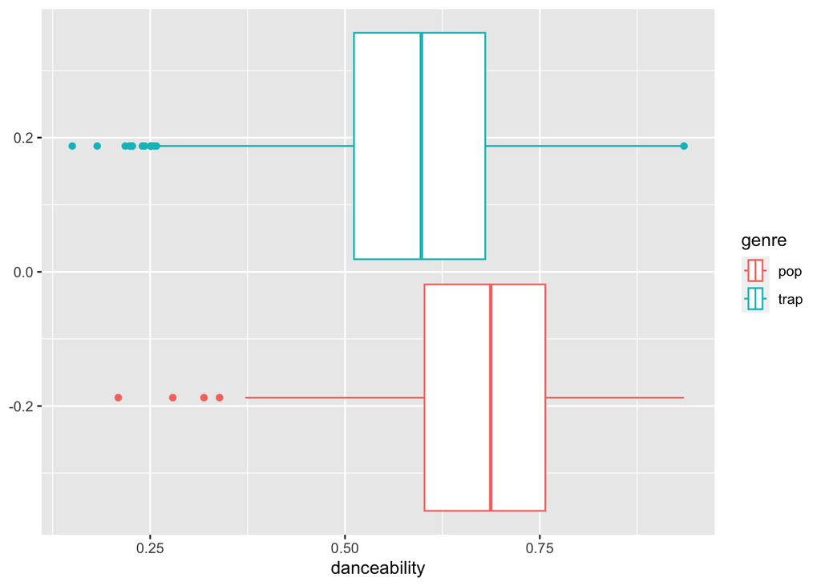

```r
## Insert Data Viz here
#Dancability
ggplot(data = genre_dat, aes(x = danceability))+
  geom_boxplot(aes(color = genre))
```

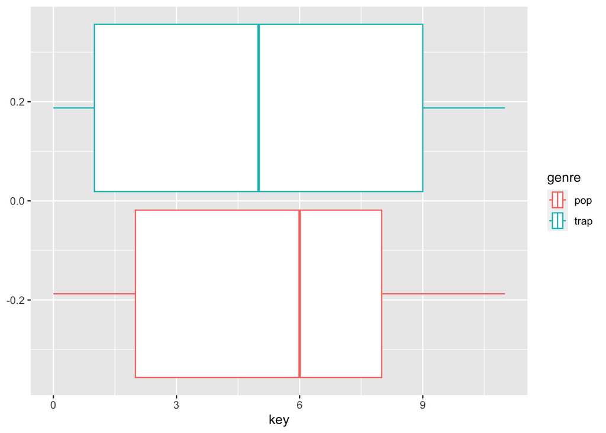

```r
#Song Length
ggplot(data = genre_dat, aes(x = key))+
  geom_boxplot(aes(color = genre))
```

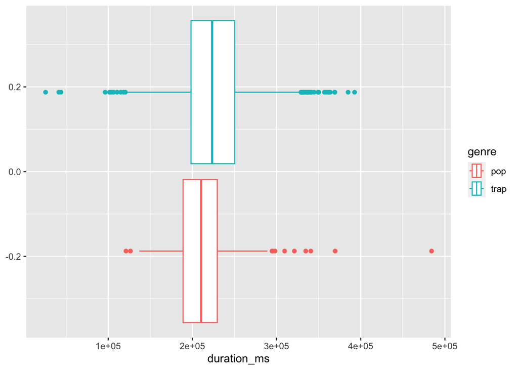

```r
#Duration
ggplot(data = genre_dat, aes(x = duration_ms))+
  geom_boxplot(aes(color = genre))
```

### **Modeling**

Create competing models that predict whether a track belongs to the pop or trap genre

You will eventually create four final candidate models:

Preprocessing. You can use the same recipe for all the models you create.

```r
set.seed(808)
#initial split of data, default 75/25
genre_split <- initial_split(genre_dat)
genre_test <- testing(genre_split)
genre_train <- training(genre_split)

#Preprocess the data
genre_rec <- recipe(genre ~., data = genre_train) %>%
  step_dummy(all_nominal(), -all_outcomes(), one_hot = TRUE) %>%
  step_normalize(all_numeric(), -all_outcomes(),)
```

1. k-nearest neighbor (Week 5)

```r
#Specify the k-nearest neighbor model
knn_spec <- nearest_neighbor(neighbors = 5) %>%
  set_engine("kknn") %>%
  set_mode("classification")

knn_fit <- knn_spec %>%
  fit(genre ~. , data = genre_train)
set.seed(808)
# 5-fold CV on the training dataset (instead of 10 for in-class demo)
cv_folds <- genre_train %>% vfold_cv(v=5)

# Create a workflow
knn_workflow <- workflow() %>%
  add_model(knn_spec) %>%
  add_recipe(genre_rec)

#Resample and cross-validate
knn_res <-
  knn_workflow %>%
  fit_resamples(
    resamples= cv_folds,
    control = control_resamples(save_pred = T)
  )

#check the performance
knn_res %>% collect_metrics()
```

```
## # A tibble: 2 × 6
##   .metric  .estimator  mean     n std_err .config
##   <chr>    <chr>      <dbl> <int>   <dbl> <chr>
## 1 accuracy binary     0.938     5 0.00335 Preprocessor1_Model1
## 2 roc_auc  binary     0.930     5 0.00445 Preprocessor1_Model1
```

```r
#---------------------------------------------------
#
#---------------------------------------------------
#Tune the model
knn_spec_tune <-
  nearest_neighbor(neighbors = tune()) %>%
  set_mode("classification") %>%
  set_engine("kknn")

#Use the tuned parameter to make a new workflow
wf_knn_tune <- workflow() %>%
  add_model(knn_spec_tune) %>%
  add_recipe(genre_rec)

# Fit the workflow on our predefined folds and a grid of hyperparameters
fit_knn_cv <-
  wf_knn_tune %>%
  tune_grid(
    cv_folds,
    grid = data.frame(neighbors = c(1,5,seq(10,100, 10)))
  )

# Check the performance with collect_metrics()
fit_knn_cv %>% collect_metrics()
```

```
## # A tibble: 24 × 7
##    neighbors .metric  .estimator  mean     n std_err .config
##        <dbl> <chr>    <chr>      <dbl> <int>   <dbl> <chr>
##  1         1 accuracy binary     0.924     5 0.00267 Preprocessor1_Model01
##  2         1 roc_auc  binary     0.843     5 0.00654 Preprocessor1_Model01
##  3         5 accuracy binary     0.938     5 0.00335 Preprocessor1_Model02
##  4         5 roc_auc  binary     0.930     5 0.00445 Preprocessor1_Model02
##  5        10 accuracy binary     0.942     5 0.00637 Preprocessor1_Model03
##  6        10 roc_auc  binary     0.955     5 0.00345 Preprocessor1_Model03
##  7        20 accuracy binary     0.947     5 0.00433 Preprocessor1_Model04
##  8        20 roc_auc  binary     0.967     5 0.00272 Preprocessor1_Model04
##  9        30 accuracy binary     0.947     5 0.00524 Preprocessor1_Model05
## 10        30 roc_auc  binary     0.971     5 0.00239 Preprocessor1_Model05
## # ℹ 14 more rows
```

```r
#---------------------------------------------------------

# The final workflow for our KNN model. Finalize_workflow takes a workflow and a set of parameters.  In this case, that set is just the best value of k
final_wf <- wf_knn_tune %>%
  finalize_workflow(select_best(fit_knn_cv, metric= "accuracy"))

# Check out the final workflow object.  Choosing accuracy for interpretability in this simple binary context
final_wf
```

```
## ══ Workflow ════════════════════════════════════════════════════════════════════
## Preprocessor: Recipe
## Model: nearest_neighbor()
##
## ── Preprocessor ────────────────────────────────────────────────────────────────
## 2 Recipe Steps
##
## • step_dummy()
## • step_normalize()
##
## ── Model ───────────────────────────────────────────────────────────────────────
## K-Nearest Neighbor Model Specification (classification)
##
## Main Arguments:
##   neighbors = 20
##
## Computational engine: kknn
```

```r
# Fitting our final workflow
final_fit <- final_wf %>% fit(data = genre_train)
# Examine the final workflow
final_fit
```

```
## ══ Workflow [trained] ══════════════════════════════════════════════════════════
## Preprocessor: Recipe
## Model: nearest_neighbor()
##
## ── Preprocessor ────────────────────────────────────────────────────────────────
## 2 Recipe Steps
##
## • step_dummy()
## • step_normalize()
##
## ── Model ───────────────────────────────────────────────────────────────────────
##
## Call:
## kknn::train.kknn(formula = ..y ~ ., data = data, ks = min_rows(20,     data, 5))
##
## Type of response variable: nominal
## Minimal misclassification: 0.05413766
## Best kernel: optimal
## Best k: 20
```

1. decision tree (Week 5)

```r
tree_spec_fixed <- decision_tree(
  cost_complexity = 0.1,
  tree_depth = 4,
  min_n = 11
) %>%
  set_engine("rpart") %>%
  set_mode("classification")

#new spec, tell the model that we are tuning hyperparams
tree_spec_tune <- decision_tree(
  cost_complexity = tune(),
  tree_depth = tune(),
  min_n = tune()) %>%
  set_engine("rpart") %>%
  set_mode("classification")

tree_spec_tune
```

```
## Decision Tree Model Specification (classification)
##
## Main Arguments:
##   cost_complexity = tune()
##   tree_depth = tune()
##   min_n = tune()
##
## Computational engine: rpart
```

```r
tree_grid <- grid_regular(cost_complexity(), tree_depth(), min_n(), levels = 5)
tree_grid
```

```
## # A tibble: 125 × 3
##    cost_complexity tree_depth min_n
##              <dbl>      <int> <int>
##  1    0.0000000001          1     2
##  2    0.0000000178          1     2
##  3    0.00000316            1     2
##  4    0.000562              1     2
##  5    0.1                   1     2
##  6    0.0000000001          4     2
##  7    0.0000000178          4     2
##  8    0.00000316            4     2
##  9    0.000562              4     2
## 10    0.1                   4     2
## # ℹ 115 more rows
```

```r
wf_tree_tune <- workflow() %>%
  add_recipe(genre_rec) %>%
    add_model(tree_spec_tune)

#set up k-fold cv. This can be used for all the algorithms
genre_cv = genre_train %>% vfold_cv(v = 10)
genre_cv
```

```
## #  10-fold cross-validation
## # A tibble: 10 × 2
##    splits             id
##    <list>             <chr>
##  1 <split [2327/259]> Fold01
##  2 <split [2327/259]> Fold02
##  3 <split [2327/259]> Fold03
##  4 <split [2327/259]> Fold04
##  5 <split [2327/259]> Fold05
##  6 <split [2327/259]> Fold06
##  7 <split [2328/258]> Fold07
##  8 <split [2328/258]> Fold08
##  9 <split [2328/258]> Fold09
## 10 <split [2328/258]> Fold10
```

```r
tree_rs <- tune_grid(
  tree_spec_tune,
  genre ~.,
  resamples = genre_cv,
    grid = tree_grid,
  metrics = metric_set(accuracy)
)
tree_rs
```

```
## # Tuning results
## # 10-fold cross-validation
## # A tibble: 10 × 4
##    splits             id     .metrics           .notes
##    <list>             <chr>  <list>             <list>
##  1 <split [2327/259]> Fold01 <tibble [125 × 7]> <tibble [0 × 3]>
##  2 <split [2327/259]> Fold02 <tibble [125 × 7]> <tibble [0 × 3]>
##  3 <split [2327/259]> Fold03 <tibble [125 × 7]> <tibble [0 × 3]>
##  4 <split [2327/259]> Fold04 <tibble [125 × 7]> <tibble [0 × 3]>
##  5 <split [2327/259]> Fold05 <tibble [125 × 7]> <tibble [0 × 3]>
##  6 <split [2327/259]> Fold06 <tibble [125 × 7]> <tibble [0 × 3]>
##  7 <split [2328/258]> Fold07 <tibble [125 × 7]> <tibble [0 × 3]>
##  8 <split [2328/258]> Fold08 <tibble [125 × 7]> <tibble [0 × 3]>
##  9 <split [2328/258]> Fold09 <tibble [125 × 7]> <tibble [0 × 3]>
## 10 <split [2328/258]> Fold10 <tibble [125 × 7]> <tibble [0 × 3]>
```

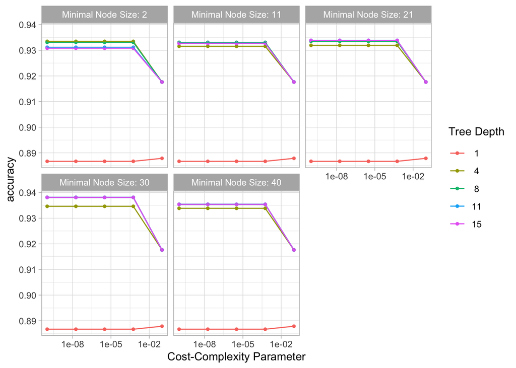

```r
autoplot(tree_rs) + theme_light()
```

```r
show_best(tree_rs)
```

```
## # A tibble: 5 × 9
##   cost_complexity tree_depth min_n .metric  .estimator  mean     n std_err
##             <dbl>      <int> <int> <chr>    <chr>      <dbl> <int>   <dbl>
## 1    0.0000000001          8    30 accuracy binary     0.938    10 0.00217
## 2    0.0000000178          8    30 accuracy binary     0.938    10 0.00217
## 3    0.00000316            8    30 accuracy binary     0.938    10 0.00217
## 4    0.000562              8    30 accuracy binary     0.938    10 0.00217
## 5    0.0000000001         11    30 accuracy binary     0.938    10 0.00217
## # ℹ 1 more variable: .config <chr>
```

```r
select_best(tree_rs)
```

```
## # A tibble: 1 × 4
##   cost_complexity tree_depth min_n .config
##             <dbl>      <int> <int> <chr>
## 1    0.0000000001          8    30 Preprocessor1_Model086
```

```r
final_tree <- finalize_model(tree_spec_tune, select_best(tree_rs))
final_tree
```

```
## Decision Tree Model Specification (classification)
##
## Main Arguments:
##   cost_complexity = 1e-10
##   tree_depth = 8
##   min_n = 30
##
## Computational engine: rpart
```

```r
#similar functions here.
final_tree_fit <- fit(final_tree, genre~.,genre_train)
#last_fit() fits on training data (like fit()), but then also evaluates on the test data.
final_tree_result <- last_fit(final_tree, genre~., genre_split )
final_tree_result$.predictions
```

```
## [[1]]
## # A tibble: 862 × 6
##    .pred_pop .pred_trap  .row .pred_class genre .config
##        <dbl>      <dbl> <int> <fct>       <fct> <chr>
##  1   0.00757     0.992      1 trap        pop   Preprocessor1_Model1
##  2   0.937       0.0629     2 pop         pop   Preprocessor1_Model1
##  3   0.937       0.0629     3 pop         pop   Preprocessor1_Model1
##  4   0.937       0.0629     4 pop         pop   Preprocessor1_Model1
##  5   0.937       0.0629     6 pop         pop   Preprocessor1_Model1
##  6   0.870       0.130      8 pop         pop   Preprocessor1_Model1
##  7   0.0753      0.925      9 trap        pop   Preprocessor1_Model1
##  8   0.95        0.05      12 pop         pop   Preprocessor1_Model1
##  9   0.870       0.130     16 pop         pop   Preprocessor1_Model1
## 10   0.3         0.7       19 trap        pop   Preprocessor1_Model1
## # ℹ 852 more rows
```

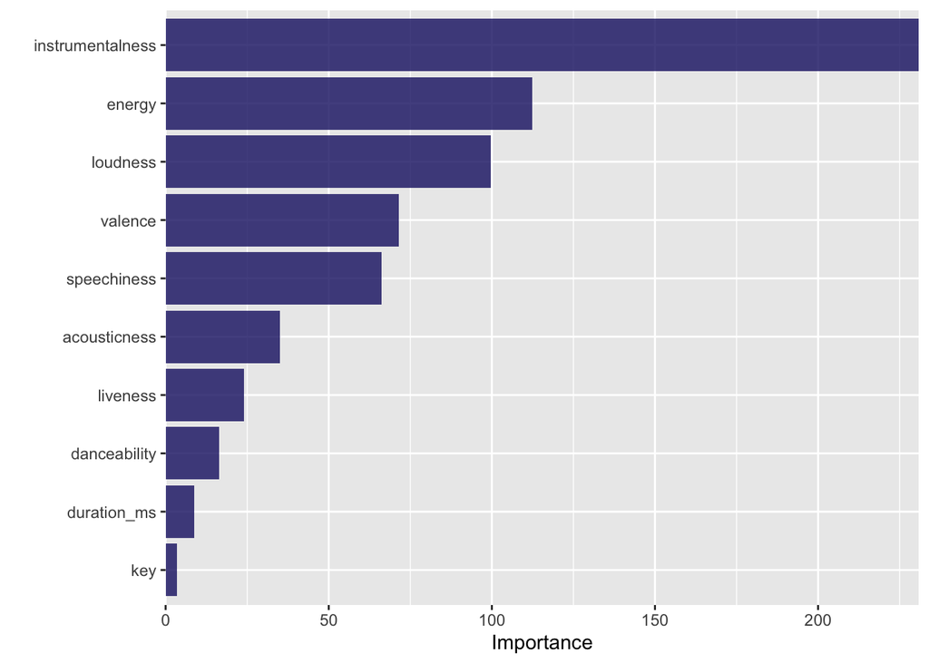

```r
final_tree_fit %>%
  vip(geom = "col", aesthetics = list(fill = "midnightblue", alpha = 0.8)) +
  scale_y_continuous(expand = c(0,0))
```

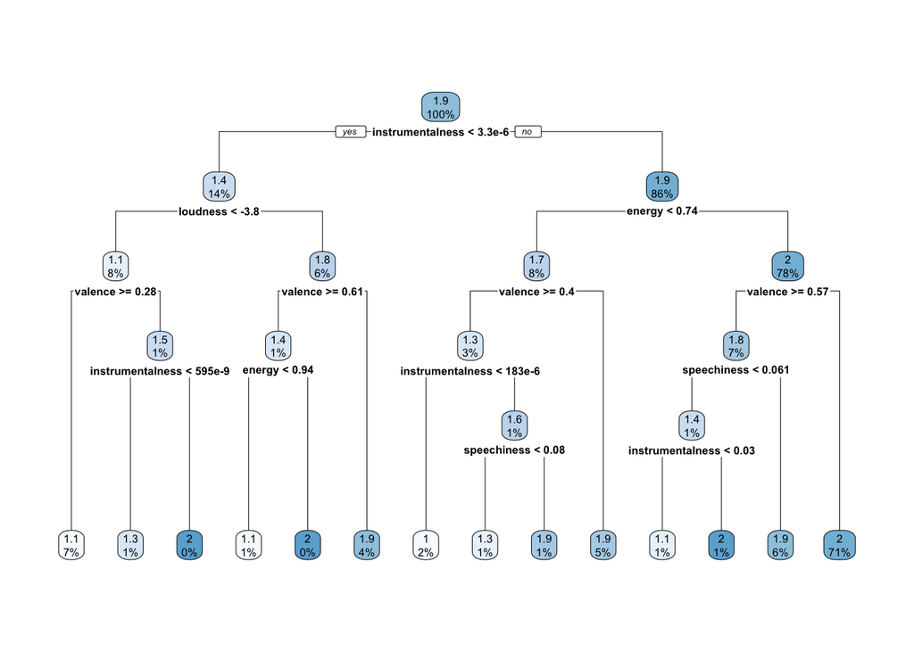

```r
#---------------------------------
genre_tree1 <- rpart(
  formula = genre ~ .,
  data    = genre_train,
  method  = "anova"
)
rpart.plot(genre_tree1)
```

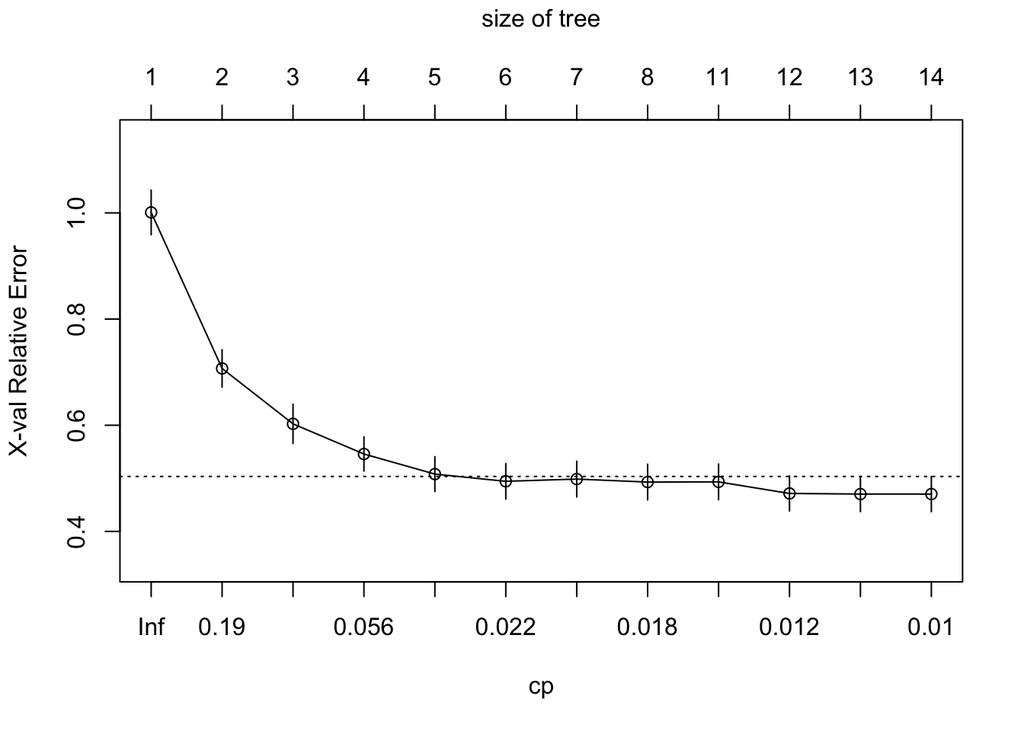

```r
plotcp(genre_tree1)
```

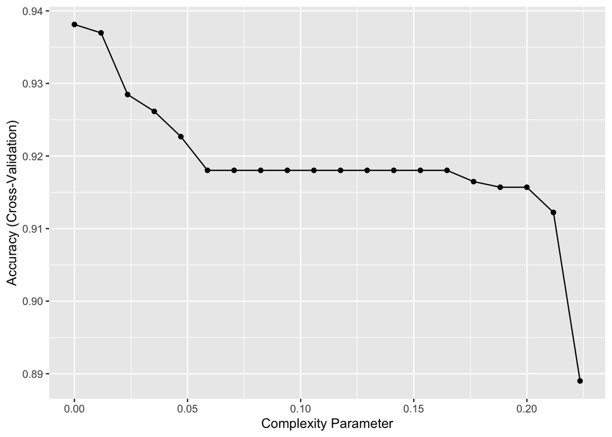

```r
# caret cross validation results
genre_tree2 <- train(
  genre ~ .,
  data = genre_train,
  method = "rpart",
  trControl = trainControl(method = "cv", number = 10),
  tuneLength = 20
)

ggplot(genre_tree2)
```

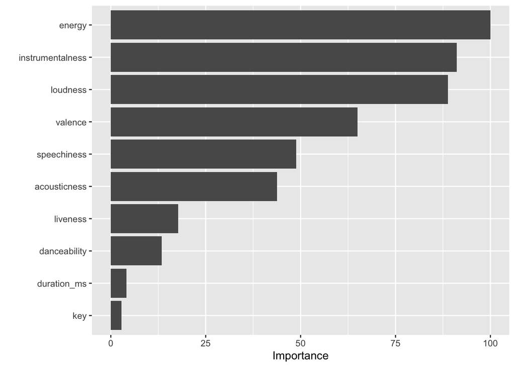

```r
vip(genre_tree2, num_features = 10)
```

1. bagged tree (Week 6)
   - bag_tree()
   - Use the “times =” argument when setting the engine during model specification to specify the number of trees. The rule of thumb is that 50-500 trees is usually sufficient. The bottom of that range should be sufficient here.

```r
# train bagged model
bag_tree <- bagging(
  formula = genre ~ .,
  data = genre_train,
  nbagg = 50,
  coob = TRUE,
  control = rpart.control(minsplit = 2, cp = 0)
)

bag2 <- train(
  genre ~ .,
  data = genre_train,
  method = "treebag",
  trControl = trainControl(method = "cv", number = 10),
  nbagg = 50,
  control = rpart.control(minsplit = 2, cp = 0)
)

bag2
```

```
## Bagged CART
##
## 2586 samples
##   12 predictor
##    2 classes: 'pop', 'trap'
##
## No pre-processing
## Resampling: Cross-Validated (10 fold)
## Summary of sample sizes: 2327, 2327, 2328, 2327, 2328, 2327, ...
## Resampling results:
##
##   Accuracy   Kappa
##   0.9555355  0.8016102
```

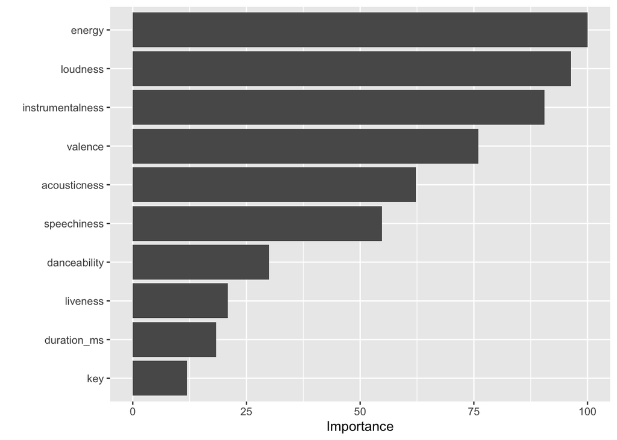

```r
# Fit trees in parallel and compute predictions on the test set
predictions <- foreach(
  icount(160),
  .packages = "rpart",
  .combine = cbind
  ) %dopar% {
    # bootstrap copy of training data
    index <- sample(nrow(genre_train), replace = TRUE)
    genre_train_boot <- genre_train[index, ]

    # fit tree to bootstrap copy
    bagged_tree <- rpart(
      genre ~ .,
      control = rpart.control(minsplit = 2, cp = 0),
      data = genre_train_boot
      )

    predict(bagged_tree, newdata = genre_test)
  }
vip::vip(bag2, num_features = 10)
```

1. random forest (Week 6)
   - rand_forest()
   - m_try() is the new hyperparameter of interest for this type of model. Make sure to include it in your tuning process

```r
# number of features
n_features <- length(setdiff(names(genre_train), "genre"))

# train a default random forest model
genre_rf1 <- ranger(
  genre ~ .,
  data = genre_train,
  mtry = floor(n_features / 3),
  respect.unordered.factors = "order",
  seed = 808
)

# get OOB RMSE
(default_rmse <- sqrt(genre_rf1$prediction.error))
```

```
## [1] 0.2024597
```

```r
# [1] 0.2024597

# create hyperparameter grid
hyper_grid <- expand.grid(
  mtry = floor(n_features * c(.05, .15, .25, .333, .4)),
  min.node.size = c(1, 3, 5, 10),
  replace = c(TRUE, FALSE),
  sample.fraction = c(.5, .63, .8),
  rmse = NA
)

for(i in seq_len(nrow(hyper_grid))) {
  # fit model for ith hyperparameter combination
  fit <- ranger(
    formula         = genre ~ .,
    data            = genre_train,
    num.trees       = n_features * 10,
    mtry            = hyper_grid$mtry[i],
    min.node.size   = hyper_grid$min.node.size[i],
    replace         = hyper_grid$replace[i],
    sample.fraction = hyper_grid$sample.fraction[i],
    verbose         = FALSE,
    seed            = 808,
    respect.unordered.factors = 'order',
  )
  # export OOB error
  hyper_grid$rmse[i] <- sqrt(fit$prediction.error)
}

# assess top 10 models
hyper_grid %>%
  arrange(rmse) %>%
  mutate(perc_gain = (default_rmse - rmse) / default_rmse * 100) %>%
  head(10)
```

```
##    mtry min.node.size replace sample.fraction      rmse perc_gain
## 1     0             1    TRUE            0.80 0.1956606 3.3582769
## 2     3             1    TRUE            0.80 0.1956606 3.3582769
## 3     3             1    TRUE            0.80 0.1956606 3.3582769
## 4     0             3    TRUE            0.80 0.2015025 0.4728159
## 5     3             3    TRUE            0.80 0.2015025 0.4728159
## 6     3             3    TRUE            0.80 0.2015025 0.4728159
## 7     0             3   FALSE            0.63 0.2024597 0.0000000
## 8     3             3   FALSE            0.63 0.2024597 0.0000000
## 9     3             3   FALSE            0.63 0.2024597 0.0000000
## 10    0             5    TRUE            0.80 0.2024597 0.0000000
```

```r
# run model with impurity-based variable importance
rf_impurity <- ranger(
  formula = genre ~ .,
  data = genre_train,
  num.trees = 2000,
  mtry = 4,
  min.node.size = 1,
  sample.fraction = .80,
  replace = FALSE,
  importance = "impurity",
  respect.unordered.factors = "order",
  verbose = FALSE,
  seed  = 808
)

# re-run model with permutation-based variable importance
rf_permutation <- ranger(
  formula = genre ~ .,
  data = genre_train,
  num.trees = 2000,
  mtry = 4,
  min.node.size = 1,
  sample.fraction = .80,
  replace = FALSE,
  importance = "permutation",
  respect.unordered.factors = "order",
  verbose = FALSE,
  seed  = 808
)

rf_impurity
```

```
## Ranger result
##
## Call:
##  ranger(formula = genre ~ ., data = genre_train, num.trees = 2000,      mtry = 4, min.node.size = 1, sample.fraction = 0.8, replace = FALSE,      importance = "impurity", respect.unordered.factors = "order",      verbose = FALSE, seed = 808)
##
## Type:                             Classification
## Number of trees:                  2000
## Sample size:                      2586
## Number of independent variables:  12
## Mtry:                             4
## Target node size:                 1
## Variable importance mode:         impurity
## Splitrule:                        gini
## OOB prediction error:             4.02 %
```

```r
rf_permutation
```

```
## Ranger result
##
## Call:
##  ranger(formula = genre ~ ., data = genre_train, num.trees = 2000,      mtry = 4, min.node.size = 1, sample.fraction = 0.8, replace = FALSE,      importance = "permutation", respect.unordered.factors = "order",      verbose = FALSE, seed = 808)
##
## Type:                             Classification
## Number of trees:                  2000
## Sample size:                      2586
## Number of independent variables:  12
## Mtry:                             4
## Target node size:                 1
## Variable importance mode:         permutation
## Splitrule:                        gini
## OOB prediction error:             4.02 %
```

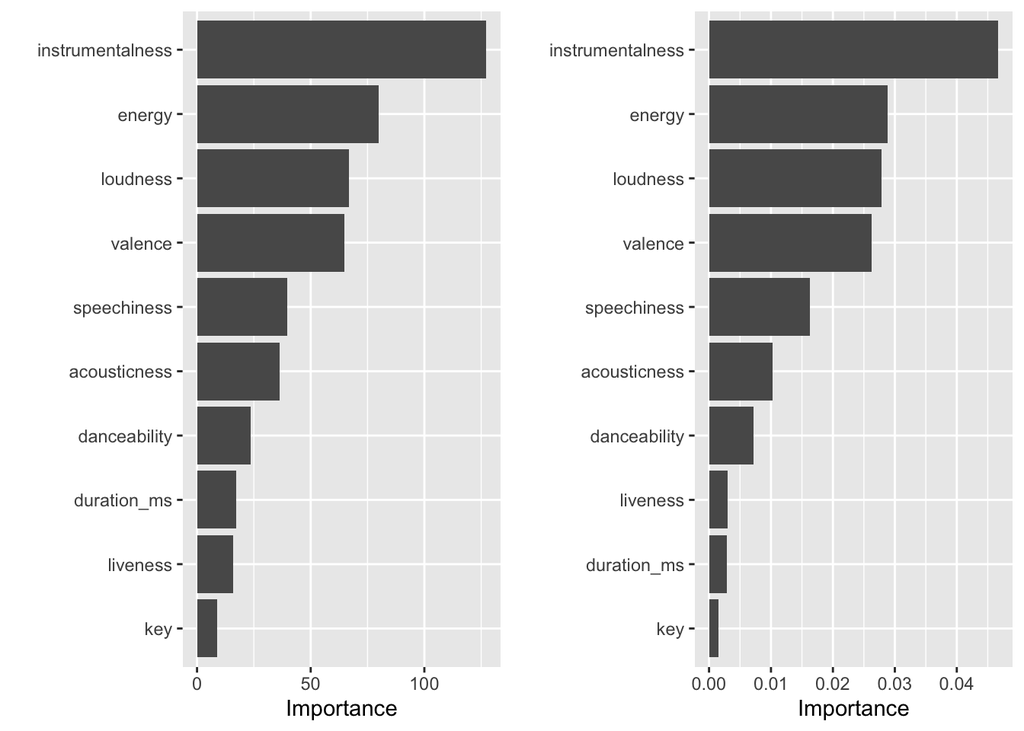

```r
p1 <- vip::vip(rf_impurity, num_features = 10)
p2 <- vip::vip(rf_permutation, num_features = 10)

gridExtra::grid.arrange(p1, p2, nrow = 1)
```

```r
rf_model = rand_forest(mtry = tune(), trees = tune()) %>% #set random forest model to tune number of trees and number of predictors sampled
  set_engine("ranger") %>% #use ranger engine
  set_mode("classification") #set classification as mode

rf_workflow = workflow() %>% #create workflow
  add_model(rf_model) %>% #add random forest model
  add_recipe(genre_rec) #add recipe

rf_workflow
```

```
## ══ Workflow ════════════════════════════════════════════════════════════════════
## Preprocessor: Recipe
## Model: rand_forest()
##
## ── Preprocessor ────────────────────────────────────────────────────────────────
## 2 Recipe Steps
##
## • step_dummy()
## • step_normalize()
##
## ── Model ───────────────────────────────────────────────────────────────────────
## Random Forest Model Specification (classification)
##
## Main Arguments:
##   mtry = tune()
##   trees = tune()
##
## Computational engine: ranger
```

```r
cv_folds = vfold_cv(genre_train, v = 5)

rf_cv_tune = rf_workflow %>%
 tune_grid(resamples = cv_folds, grid = 10) #use cross validation to tune mtry and trees parameters
```

```
## i Creating pre-processing data to finalize unknown parameter: mtry
```

```r
collect_metrics(rf_cv_tune) #get metrics from tuning cv to pick best model
```

```
## # A tibble: 20 × 8
##     mtry trees .metric  .estimator  mean     n std_err .config
##    <int> <int> <chr>    <chr>      <dbl> <int>   <dbl> <chr>
##  1     3   983 accuracy binary     0.957     5 0.00264 Preprocessor1_Model01
##  2     3   983 roc_auc  binary     0.983     5 0.00300 Preprocessor1_Model01
##  3     8   608 accuracy binary     0.954     5 0.00287 Preprocessor1_Model02
##  4     8   608 roc_auc  binary     0.979     5 0.00275 Preprocessor1_Model02
##  5     6  1401 accuracy binary     0.955     5 0.00283 Preprocessor1_Model03
##  6     6  1401 roc_auc  binary     0.980     5 0.00276 Preprocessor1_Model03
##  7     1   356 accuracy binary     0.950     5 0.00391 Preprocessor1_Model04
##  8     1   356 roc_auc  binary     0.983     5 0.00346 Preprocessor1_Model04
##  9    10  1675 accuracy binary     0.952     5 0.00316 Preprocessor1_Model05
## 10    10  1675 roc_auc  binary     0.977     5 0.00267 Preprocessor1_Model05
## 11     9  1242 accuracy binary     0.954     5 0.00277 Preprocessor1_Model06
## 12     9  1242 roc_auc  binary     0.978     5 0.00262 Preprocessor1_Model06
## 13    11   526 accuracy binary     0.950     5 0.00354 Preprocessor1_Model07
## 14    11   526 roc_auc  binary     0.976     5 0.00255 Preprocessor1_Model07
## 15     5  1897 accuracy binary     0.955     5 0.00283 Preprocessor1_Model08
## 16     5  1897 roc_auc  binary     0.980     5 0.00306 Preprocessor1_Model08
## 17     4  1007 accuracy binary     0.956     5 0.00267 Preprocessor1_Model09
## 18     4  1007 roc_auc  binary     0.982     5 0.00278 Preprocessor1_Model09
## 19     8    97 accuracy binary     0.954     5 0.00290 Preprocessor1_Model10
## 20     8    97 roc_auc  binary     0.977     5 0.00361 Preprocessor1_Model10
```

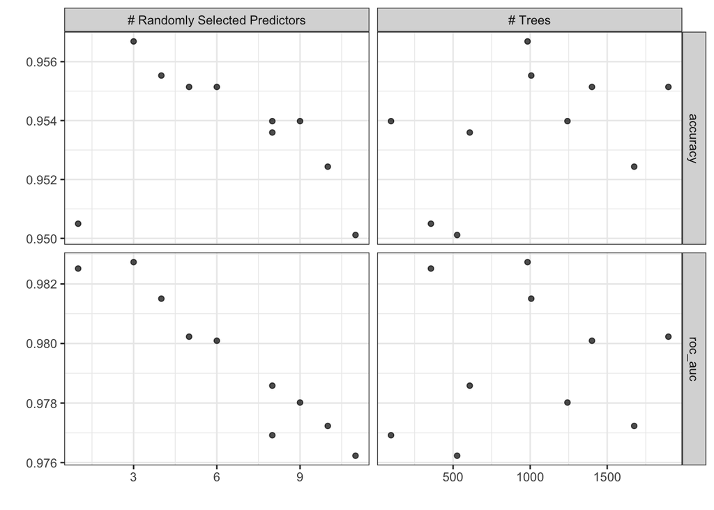

```r
autoplot(rf_cv_tune) + #plot cv results for parameter tuning
  theme_bw()
```

```r
rf_best = show_best(rf_cv_tune, n = 1, metric = "roc_auc") #get metrics for best random forest model

rf_final = finalize_workflow(rf_workflow, select_best(rf_cv_tune, metric = "roc_auc")) #finalize random forest model with best parameters

train_fit_rf = fit(rf_final, genre_train) #fit the RF model to the training set

test_predict_rf = predict(train_fit_rf, genre_test) %>% #get prediction probabilities for test
  bind_cols(genre_test) %>%  #bind to testing column
  mutate(genre = as.factor(genre))

test_predict2_rf = predict(train_fit_rf, genre_test, type = "prob") %>% #get testing prediction
  bind_cols(genre_test) %>%  #bind to testing column
  mutate(genre = as.factor(genre))

accuracy(test_predict_rf, truth = genre, estimate = .pred_class) #get accuracy of testing prediction
```

```
## # A tibble: 1 × 3
##   .metric  .estimator .estimate
##   <chr>    <chr>          <dbl>
## 1 accuracy binary         0.966
```

```r
m1 = test_predict_rf %>%
  conf_mat(truth = genre, estimate = .pred_class) %>% #create confusion matrix
  autoplot(type = "heatmap") + #plot confusion matrix with heatmap
  theme_bw() + #change theme
  theme(axis.text.x = element_text(angle = 30, hjust=1)) +
  #rotate axis labels
  labs(title = "Random Forest")
```

The random forests model was the most accurate model of the four models tested.

```r
df <- data.frame(
  type = c("KNN", "Decision Tree", "Bagging", "Random Forests"),
  accuracy = c(0.9458623, 0.9381237, 0.9555355, 0.9663573)
)

kable(df)
```

| type | accuracy |
| --- | --- |
| KNN | 0.9458623 |
| Decision Tree | 0.9381237 |
| Bagging | 0.9555355 |
| Random Forests | 0.9663573 |

Use appropriate performance evaluation metric(s) for this classification task. A table would be a good way to display your comparison. Use at least one visualization illustrating your model results.